# Global Health Expenditure by Demographics

Arnav Srivastava

2/28/2020

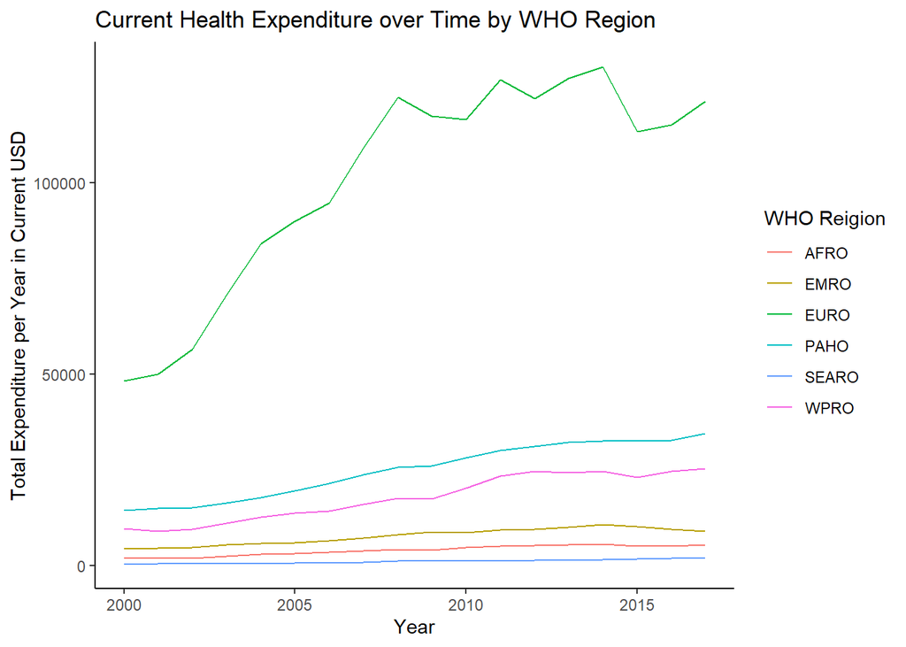

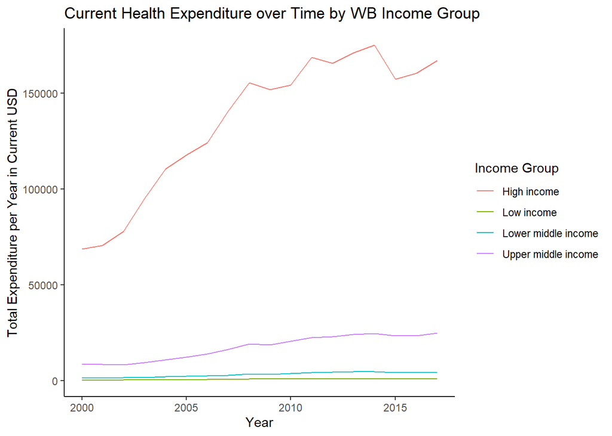

## Background

For this project, I strive to analyze how global health expenditure varies based on economic and geographic factors. From the World Bank (WB), the Global Data Health Exchange, and the World Health Organization (WHO), I have gathered data regarding population sex/age demographics; the estimated the burden of diseases, injuries, and risk factors; historic health care spending and health care spending projections (1995-2050); current health expenditure per capita and per general government expenditure; and domestic/foreign expenditure for healthcare; for 195 countries from 2000-2018. I plan on grouping countries by WB Income brackets and WHO Reigional Brackets to explore how the collected variables effect the proportional spending on health through an income and reigional lens. Finally, I aim to analyze the affects (new cases, casualities, etc.) of the corona virus.

For instance, I hope to answer questions such as: with what demographics and income bracket leads countries to maximize spending on infectious diseases (which socioeconomic conditions maximize the the balance between spending on healthcare per capita with respect incidence/impact to infectious disease in the area?)

This data can be found on my GitHub repo at https://github.com/arnavinator/gov1005-final_project

## About Me

My name is Arnav Srivastava, and I am currently a first-year at Harvard College. I am fascinated by global health and improving accessibility to the ever-growing frontier of science; I hope to concentrate in biomedical engineering, electrical engineering, or statistics, and help advance the health of our global community.